# Lab 5 Wide and Deep Network

47491968 Yuankai Liu  
47511663 Jianing Zhao  
47564911 Yang Peng

# 1.Preparation

## 1.1 Define and prepare class variables

In this lab, we will be using the "IBM HR Analytics Employee Attrition & Performance" dataset. This dataset has been prepared for usage in predicting attrition of valuable employees. This can give more reference to employer or HR to maintain employees' stability and motivation better.

```python
from matplotlib import pyplot as plt
import numpy as np
import pandas as pd
from sklearn.cross_validation import train_test_split
from sklearn.metrics import accuracy_score,f1_score
df=pd.read_csv('HR.csv')
```

First, we removed several variables that are not useful for our analysis: EmployeeCount, Over18, StandardHours, EmployeeNumber. Because EmployeeCount and EmployeeNumber are the identifiers, and the value of features of Over18 and StandardHours are all same.

```python
df_drop=df.drop(['EmployeeCount','Over18','StandardHours','EmployeeNumber'],axis=1)
df_drop.info()
```

```
<class 'pandas.core.frame.DataFrame'>
RangeIndex: 1470 entries, 0 to 1469
Data columns (total 31 columns):
Age                         1470 non-null int64
Attrition                   1470 non-null object
BusinessTravel              1470 non-null object
DailyRate                   1470 non-null int64
Department                  1470 non-null object
DistanceFromHome            1470 non-null int64
Education                   1470 non-null int64
EducationField              1470 non-null object
EnvironmentSatisfaction     1470 non-null int64
Gender                      1470 non-null object
HourlyRate                  1470 non-null int64
JobInvolvement              1470 non-null int64
JobLevel                    1470 non-null int64
JobRole                     1470 non-null object
JobSatisfaction             1470 non-null int64
MaritalStatus               1470 non-null object
MonthlyIncome               1470 non-null int64
MonthlyRate                 1470 non-null int64
NumCompaniesWorked          1470 non-null int64
OverTime                    1470 non-null object
PercentSalaryHike           1470 non-null int64
PerformanceRating           1470 non-null int64
RelationshipSatisfaction    1470 non-null int64
StockOptionLevel            1470 non-null int64
TotalWorkingYears           1470 non-null int64
TrainingTimesLastYear       1470 non-null int64
WorkLifeBalance             1470 non-null int64
YearsAtCompany              1470 non-null int64
YearsInCurrentRole          1470 non-null int64
YearsSinceLastPromotion     1470 non-null int64
YearsWithCurrManager        1470 non-null int64
dtypes: int64(23), object(8)
memory usage: 356.1+ KB
```

The dataset's features remaining are comprised of a mix of nominal and numeric data types. Below is the description of dataset that we used for classification. This is a binary classification model, and attrition is the objective.

[output not shown]

Then we splitted numeric and categorical features and made standardization.

```python
from sklearn.preprocessing import LabelEncoder
from sklearn.preprocessing import StandardScaler
encoders = dict()
headers=df_drop.columns.values.tolist()
```

```python
categorical_headers=['BusinessTravel','Department','EducationField','Gender','JobRole','MaritalStatus','OverTime']
numeric_headers= list(set(headers)^set(categorical_headers+['Attrition']))
print(categorical_headers)
print(numeric_headers)
```

[output not shown]

```python
encoders = dict()
for col in categorical_headers+['Attrition']:
    df_drop[col] = df_drop[col].str.strip()
    if col=="Attrition":
        tmp = LabelEncoder()
        df_drop[col] = tmp.fit_transform(df_drop[col])
    else:
        encoders[col] = LabelEncoder()
        df_drop[col+'_int'] = encoders[col].fit_transform(df_drop[col])

for col in numeric_headers:
    df_drop[col] = df_drop[col].astype(np.float)
    ss = StandardScaler()
    df_drop[col] = ss.fit_transform(df_drop[col].values.reshape(-1, 1))

categorical_headers_ints = [x+'_int' for x in categorical_headers]
feature_columns = categorical_headers_ints+numeric_headers
```

```python
categorical_headers_ints = [x+'_int' for x in categorical_headers]
feature_columns = categorical_headers_ints+numeric_headers
```

```python
df_drop.head()
```

|  | Age | Attrition | BusinessTravel | DailyRate | Department | DistanceFromHome | Education | EducationField | EnvironmentSatisfaction | Gender | ... | YearsInCurrentRole | YearsSinceLastPromotion | YearsWithCurrManager | BusinessTravel_int | Department_int | EducationField_int | Gender_int | JobRole_int | MaritalStatus_int | OverTime_int |
| --- | --- | --- | --- | --- | --- | --- | --- | --- | --- | --- | --- | --- | --- | --- | --- | --- | --- | --- | --- | --- | --- |
| 0 | 0.446350 | 1 | Travel_Rarely | 0.742527 | Sales | -1.010909 | -0.891688 | Life Sciences | -0.660531 | Female | ... | -0.063296 | -0.679146 | 0.245834 | 2 | 2 | 1 | 0 | 7 | 2 | 1 |
| 1 | 1.322365 | 0 | Travel_Frequently | -1.297775 | Research & Development | -0.147150 | -1.868426 | Life Sciences | 0.254625 | Male | ... | 0.764998 | -0.368715 | 0.806541 | 1 | 1 | 1 | 1 | 6 | 1 | 0 |
| 2 | 0.008343 | 1 | Travel_Rarely | 1.414363 | Research & Development | -0.887515 | -0.891688 | Other | 1.169781 | Male | ... | -1.167687 | -0.679146 | -1.155935 | 2 | 1 | 4 | 1 | 2 | 2 | 1 |
| 3 | -0.429664 | 0 | Travel_Frequently | 1.461466 | Research & Development | -0.764121 | 1.061787 | Life Sciences | 1.169781 | Female | ... | 0.764998 | 0.252146 | -1.155935 | 1 | 1 | 1 | 0 | 6 | 1 | 1 |
| 4 | -1.086676 | 0 | Travel_Rarely | -0.524295 | Research & Development | -0.887515 | -1.868426 | Medical | -1.575686 | Male | ... | -0.615492 | -0.058285 | -0.595227 | 2 | 1 | 3 | 1 | 2 | 1 | 0 |

5 rows × 38 columns

Split our data into training and testing splits by 80%/20%, and the process of splits are stratified.

```python
df_train, df_test = train_test_split(df_drop, test_size=0.2, stratify=df['Attrition'])
X_train=df_train.drop(['Attrition'], axis = 1)
y_train=df_train['Attrition']
X_test=df_test.drop(['Attrition'], axis = 1)
y_test=df_test['Attrition']
```

## 1.2 Cross-Product Features

After looking at all useful features in our dataset, we need to find features that can be combined into cross-product features for the purpose of memorization techniques in wide networks. Finally, we choosed three pair of cross-product features.

```
[Gender,MaritalStatus]
[BusinessTravel,OverTime]
[EducationField,JobRole]
```

**Gender and MaritalStatus**: Gender is an important factor in labour market, and male and female have natural differences in some aspects. Marital status is also a factor that can not be ignored when considering attrition. Gender and MaritalStatus cross-products is meaningful because we can make an in-depth study of employees with different genders and marital status. Certain combinations may have varying correlations to attrition, and that's what we expect.

**BusinessTravel and OverTime**: These two features seem that they could be logically grouped together. OverTime can increase employee's work pressure, and BusinessTravel is a direct factor to arrtition. Therefore, the combinations of these two features may have postive influence, certain combination may have high possibility of attrition, such as over time and frequent business travel.

**EducationField and JobRole**: Education field and job role is kind of logically related when it comes to attrition. Under normal circumstances, if the job role of employee is related with education field, this employee we think has lower possibility of attrition. So EducationField and JobRole cross-products will be helpful for us to make better classification we think.

```python
cross_columns = [['EducationField','JobRole'],
                 ['Gender','MaritalStatus'],
                 ['BusinessTravel','OverTime']]
```

## 1.3 Evaluation Metrics

Genarally, We use accuracy, precision, recall, f1-score, ROC-AUC to evalate the model in binary classification problems.

**Accuracy**: It is the most common and basic evaluation metric.

**Precision**: It is the proportion of "true" samples judged by all systems that is truly true, that is, TP/(TP+FP).

**Recall**: It is the proportion of “true” that is judged to be TP/(TP+FN) in all samples that are truly true.

**F1-score**: The metric designed to comprehensively consider the precision and recall.

**ROC-AUC**: It is the curve of TP vs FP.

But the objective in different situation is totally diferent, which means in determining the most important evaluation metric, it is important to reiterate the business case with our classification model. **For instance**, email filtering spam, you want it to be more comprehensive (detect all the junk, but there is a lot of useful information is also judged as junk), or you want it to be as accurate as possible (do not always detect useful email as junk)? Obviously, we think that False Positive's damage is greater than False Negative: the loss of important mail if it is sentenced to junk is far greater than the amount of spam in the inbox. **However**, for the prediction of the earthquake, we hope that recall is very high, that is, we want to predict each earthquake. At this time we can sacrifice percision.

As we stated before, our binary classification problem aims to predict attrition of valuable employees and then let employer know whether employee is at risk for attrition.

Therefore, we believe that we are most concerned about True-Positive and it is important to reduce the number of False-Negatives. In the context of our classification problem, false-negative will cause the situation that the employer and HR don't realize the intention of some employees' attrition. We hope that Employer and HR can use this model to get information that employees' intention of attrition in advance and then make some adjustment to Prevent these kind of situations happening. It would be better to give some employee a false-positive label, for the worst situation.

Given the analysis above of our business case, we think that the most appropriate evaluation metric for our model would be **Recall Score**. We decided to use Recall as our scoring metric. because it is important that the model's predictions are true-positive, and it is necessary to penalize the model for giving false-negatives.

## 1.4 Cross validation methods

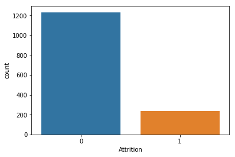

```python
import seaborn as sns
sns.countplot(data=df_drop,x='Attrition')
plt.show()
```

In addition to deciding on an evaluation metric that is more appropriate for our business use case, we must also determine the best method by which to divide our data into training and testing splits. Our dataset are approximate 1500 instances.

Once again, we are haunted by the curse of unbalanced classes. As far as possible to ensure that classification of data in the test set and training the same proportion, we need to split the data.

First of all, we split our data into training and testing splits by 80%/20%, and the process of splits are stratified. The testing set will be used for the our model and MLP model to compare the performance.

Then, in the cases of class imbalance and the size limitation of our dataset, we would want to use a stratified 10-fold cross validation to help ensure a proper ratio between the classes are represented within each fold and get better performance of our model. We use this stratified 10-fold cross validation set to evaluate our model.

# 2.Modeling

For our classification model, we will be experimenting with several implementations of neural networks. We will integrate both wide and deep network architectures into one network and then experiment with different ways.

## 2.1 Several Model Performence

First, we created a original wide and deep network. Then we changed loss function, optimizer and added dropout layer to examine performance of different model.

One thing that should be mentioned is that Keras removed some evaluation metrics, such as percision and recall, and only remain accuracy as a metrics to examine the performance.

```python
from sklearn import metrics as mt
from keras.models import Sequential
from keras.layers import Dense, Activation, Input
from keras.layers import Embedding, Flatten, Merge, concatenate
from keras.models import Model
```

```python
embed_branches = []
X_ints_train = []
X_ints_test = []
all_inputs = []
all_branch_outputs = []
X_train_num =  df_train[numeric_headers].values
X_test_num = df_test[numeric_headers].values

for cols in cross_columns:
    # encode crossed columns as ints for the embedding
    enc = LabelEncoder()

    # create crossed labels
    # needs to be commented better, Eric!
    X_crossed_train = df_train[cols].apply(lambda x: '_'.join(x), axis=1)
    X_crossed_test = df_test[cols].apply(lambda x: '_'.join(x), axis=1)

    enc.fit(np.hstack((X_crossed_train.values,  X_crossed_test.values)))
    X_crossed_train = enc.transform(X_crossed_train)
    X_crossed_test = enc.transform(X_crossed_test)
    X_ints_train.append( X_crossed_train )
    X_ints_test.append( X_crossed_test )

    # get the number of categories
    N = max(X_ints_train[-1]+1) # same as the max(df_train[col])

    # create embedding branch from the number of categories
    inputs = Input(shape=(1,),dtype='int32', name = '_'.join(cols))
    all_inputs.append(inputs)
    x = Embedding(input_dim=N, output_dim=int(np.sqrt(N)), input_length=1)(inputs)
    x = Flatten()(x)
    all_branch_outputs.append(x)

# merge the branches together
wide_branch = concatenate(all_branch_outputs)

# reset this input branch
all_branch_outputs = []
# add in the embeddings
for col in categorical_headers_ints:
    # encode as ints for the embedding
    X_ints_train.append( df_train[col].values )
    X_ints_test.append( df_test[col].values )

    # get the number of categories
    N = max(X_ints_train[-1]+1) # same as the max(df_train[col])

    # create embedding branch from the number of categories
    inputs = Input(shape=(1,),dtype='int32', name=col)
    all_inputs.append(inputs)
    x = Embedding(input_dim=N, output_dim=int(np.sqrt(N)), input_length=1)(inputs)
    x = Flatten()(x)
    all_branch_outputs.append(x)

# also get a dense branch of the numeric features
all_inputs.append(Input(shape=(X_train_num.shape[1],),sparse=False,name='numeric_data'))
x = Dense(units=20, activation='relu')(all_inputs[-1])
all_branch_outputs.append( x )

# merge the branches together
deep_branch = concatenate(all_branch_outputs)
deep_branch = Dense(units=50,activation='relu')(deep_branch)
deep_branch = Dense(units=10,activation='relu')(deep_branch)

final_branch = concatenate([wide_branch, deep_branch])
final_branch = Dense(units=1,activation='sigmoid')(final_branch)

model = Model(inputs=all_inputs, outputs=final_branch)

model.compile(optimizer='adagrad',
              loss='mean_squared_error',
              metrics=['accuracy'])

model.fit(X_ints_train+ [X_train_num],
        y_train, epochs=50, batch_size=32, verbose=0,validation_split=0.2)
```

```
<keras.callbacks.History at 0x20b599d9470>
```

The performance of original model.

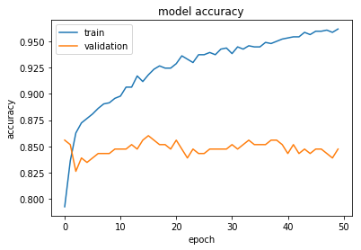

```python
import matplotlib.pyplot as plt

plt.plot()
plt.plot(model.history.history['acc'])
plt.plot(model.history.history['val_acc'])
plt.title('model accuracy')
plt.ylabel('accuracy')
plt.xlabel('epoch')
plt.legend(['train', 'validation'], loc='upper left')
plt.show()
```

```python
model2 = Model(inputs=all_inputs, outputs=final_branch)

model2.compile(optimizer='adagrad',
              loss='binary_crossentropy',
              metrics=['accuracy'])

model2.fit(X_ints_train+ [X_train_num],
        y_train, epochs=50, batch_size=32, verbose=0,validation_split=0.2)
```

```
<keras.callbacks.History at 0x20b5beaf5c0>
```

The performance of model by using binary_crossentropy loss function.

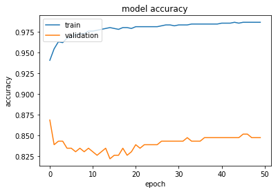

```python
import matplotlib.pyplot as plt
plt.plot()
plt.plot(model2.history.history['acc'])
plt.plot(model2.history.history['val_acc'])
plt.title('model accuracy')
plt.ylabel('accuracy')
plt.xlabel('epoch')
plt.legend(['train', 'validation'], loc='upper left')
plt.show()
```

```python
model3 = Model(inputs=all_inputs, outputs=final_branch)

model3.compile(optimizer='sgd',
              loss='binary_crossentropy',
              metrics=['accuracy'])

model3.fit(X_ints_train+ [X_train_num],
        y_train, epochs=50, batch_size=32, verbose=0,validation_split=0.2)
```

```
<keras.callbacks.History at 0x20b55b75198>
```

The performance of model by using binary_crossentropy loss function and sgd optimizer.

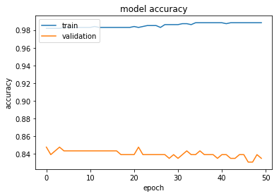

```python
import matplotlib.pyplot as plt
plt.plot()
plt.plot(model3.history.history['acc'])
plt.plot(model3.history.history['val_acc'])
plt.title('model accuracy')
plt.ylabel('accuracy')
plt.xlabel('epoch')
plt.legend(['train', 'validation'], loc='upper left')
plt.show()
```

```python
from keras.layers import Dropout
embed_branches = []
X_ints_train = []
X_ints_test = []
all_inputs = []
all_branch_outputs = []
X_train_num =  df_train[numeric_headers].values
X_test_num = df_test[numeric_headers].values

for cols in cross_columns:
    # encode crossed columns as ints for the embedding
    enc = LabelEncoder()

    # create crossed labels
    # needs to be commented better, Eric!
    X_crossed_train = df_train[cols].apply(lambda x: '_'.join(x), axis=1)
    X_crossed_test = df_test[cols].apply(lambda x: '_'.join(x), axis=1)

    enc.fit(np.hstack((X_crossed_train.values,  X_crossed_test.values)))
    X_crossed_train = enc.transform(X_crossed_train)
    X_crossed_test = enc.transform(X_crossed_test)
    X_ints_train.append( X_crossed_train )
    X_ints_test.append( X_crossed_test )

    # get the number of categories
    N = max(X_ints_train[-1]+1) # same as the max(df_train[col])

    # create embedding branch from the number of categories
    inputs = Input(shape=(1,),dtype='int32', name = '_'.join(cols))
    all_inputs.append(inputs)
    x = Embedding(input_dim=N, output_dim=int(np.sqrt(N)), input_length=1)(inputs)
    x = Flatten()(x)
    all_branch_outputs.append(x)

# merge the branches together
wide_branch = concatenate(all_branch_outputs)

# reset this input branch
all_branch_outputs = []
# add in the embeddings
for col in categorical_headers_ints:
    # encode as ints for the embedding
    X_ints_train.append( df_train[col].values )
    X_ints_test.append( df_test[col].values )

    # get the number of categories
    N = max(X_ints_train[-1]+1) # same as the max(df_train[col])

    # create embedding branch from the number of categories
    inputs = Input(shape=(1,),dtype='int32', name=col)
    all_inputs.append(inputs)
    x = Embedding(input_dim=N, output_dim=int(np.sqrt(N)), input_length=1)(inputs)
    x = Flatten()(x)
    all_branch_outputs.append(x)

# also get a dense branch of the numeric features
all_inputs.append(Input(shape=(X_train_num.shape[1],),sparse=False,name='numeric_data'))
x = Dense(units=20, activation='relu')(all_inputs[-1])
all_branch_outputs.append( x )

# merge the branches together
deep_branch = concatenate(all_branch_outputs)
deep_branch = Dense(units=50,activation='relu')(deep_branch)
deep_branch = Dropout(0.25)(deep_branch)
deep_branch = Dense(units=10,activation='relu')(deep_branch)

final_branch = concatenate([wide_branch, deep_branch])
final_branch = Dense(units=1,activation='sigmoid')(final_branch)

model = Model(inputs=all_inputs, outputs=final_branch)

model.compile(optimizer='adagrad',
              loss='mean_squared_error',
              metrics=['accuracy'])

model.fit(X_ints_train+ [X_train_num],
        y_train, epochs=50, batch_size=32, verbose=0,validation_split=0.2)
```

```
<keras.callbacks.History at 0x20b5b84ea58>
```

The performance of model by adding dropout layer.

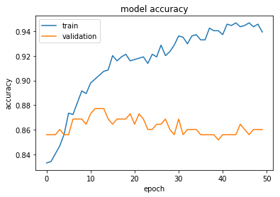

```python
import matplotlib.pyplot as plt
plt.plot()
plt.plot(model.history.history['acc'])
plt.plot(model.history.history['val_acc'])
plt.title('model accuracy')
plt.ylabel('accuracy')
plt.xlabel('epoch')
plt.legend(['train', 'validation'], loc='upper left')
plt.show()
```

We made several chances and the performance are nearly same, the accuracy of validation is 85%~86%.

## 2.2 Changing the layers

```python
model_list1= []
yhat_list1 = []
y_test_list1 = []

skf = StratifiedKFold(n_splits=10, shuffle=True)
for i, (train_indices, validation_indices) in enumerate(skf.split(X_train, y_train)):
    embed_branches = []
    X_ints_train = []
    X_ints_test = []
    all_inputs = []
    all_branch_outputs = []

    df_train_cv = df_train.iloc[train_indices]
    df_validation_cv = df_train.iloc[validation_indices]
    X_train_num =  df_train_cv[feature_columns].values
    X_test_num =  df_validation_cv[feature_columns].values
    y_train_t = df_train_cv['Attrition'].values.astype(np.int)
    y_test_t = df_validation_cv['Attrition'].values.astype(np.int)

    for cols in cross_columns:
        # encode crossed columns as ints for the embedding
        enc = LabelEncoder()

        # create crossed labels
        # needs to be commented better, Eric!
        X_crossed_train = df_train_cv[cols].apply(lambda x: '_'.join(x), axis=1)
        X_crossed_test = df_validation_cv[cols].apply(lambda x: '_'.join(x), axis=1)

        enc.fit(np.hstack((X_crossed_train.values,  X_crossed_test.values)))
        X_crossed_train = enc.transform(X_crossed_train)
        X_crossed_test = enc.transform(X_crossed_test)
        X_ints_train.append( X_crossed_train )
        X_ints_test.append( X_crossed_test )

        # get the number of categories
        N = max(X_ints_train[-1]+1) # same as the max(df_train[col])

        # create embedding branch from the number of categories
        inputs = Input(shape=(1,),dtype='int32', name = '_'.join(cols))
        all_inputs.append(inputs)
        x = Embedding(input_dim=N, output_dim=int(np.sqrt(N)), input_length=1)(inputs)
        x = Flatten()(x)
        all_branch_outputs.append(x)

    # merge the branches together
    wide_branch = concatenate(all_branch_outputs)

    # reset this input branch
    all_branch_outputs = []
    # add in the embeddings
    for col in categorical_headers_ints:
        # encode as ints for the embedding
        X_ints_train.append( df_train_cv[col].values )
        X_ints_test.append( df_test_cv[col].values )

        # get the number of categories
        N = max(X_ints_train[-1]+1) # same as the max(df_train[col])

        # create embedding branch from the number of categories
        inputs = Input(shape=(1,),dtype='int32', name=col)
        all_inputs.append(inputs)
        x = Embedding(input_dim=N, output_dim=int(np.sqrt(N)), input_length=1)(inputs)
        x = Flatten()(x)
        all_branch_outputs.append(x)

    # also get a dense branch of the numeric features
    all_inputs.append(Input(shape=(X_train_num.shape[1],),sparse=False,name='numeric_data'))
    x = Dense(units=20, activation='relu')(all_inputs[-1])
    all_branch_outputs.append( x )

    # merge the branches together
    deep_branch = concatenate(all_branch_outputs)
    deep_branch = Dense(units=50,activation='relu')(deep_branch)
    deep_branch = Dense(units=10,activation='relu')(deep_branch)

    final_branch = concatenate([wide_branch, deep_branch])
    final_branch = Dense(units=1,activation='sigmoid')(final_branch)

    modeltemp = Model(inputs=all_inputs, outputs=final_branch)

    modeltemp.compile(optimizer='adagrad',
                  loss='mean_squared_error',
                  metrics=['accuracy'])

    modeltemp.fit(X_ints_train+ [X_train_num],
            y_train_t, epochs=50, batch_size=32, verbose=0)
    model_list1.append(modeltemp)
    yhat_temp = np.round(modeltemp.predict(X_ints_test + [X_test_num]))
    yhat_list1.append(yhat_temp)
    y_test_list1.append(y_test_t)
```

The recall score of test set in original model.

```
(0.095263157894736841, 0.47368421052631576)
```

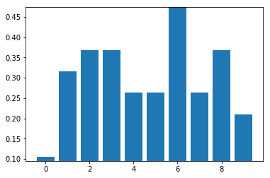

```python
scores1=[]
for i in range(0, len(yhat_list1)):
    scores1.append(mt.recall_score(y_test_list1[i],yhat_list1[i]))
plt.bar(range(len(scores1)),scores1)
plt.ylim([min(scores1)-0.01,max(scores1)])
```

Here we added two dense layers to make a new model.

```python
model_list2= []
yhat_list2 = []
y_test_list2 = []

skf = StratifiedKFold(n_splits=10, shuffle=True)
for i, (train_indices, validation_indices) in enumerate(skf.split(X_train, y_train)):
    embed_branches = []
    X_ints_train = []
    X_ints_test = []
    all_inputs = []
    all_branch_outputs = []

    df_train_cv = df_train.iloc[train_indices]
    df_validation_cv = df_train.iloc[validation_indices]
    X_train_num =  df_train_cv[feature_columns].values
    X_test_num =  df_validation_cv[feature_columns].values
    y_train_t = df_train_cv['Attrition'].values.astype(np.int)
    y_test_t = df_validation_cv['Attrition'].values.astype(np.int)

    for cols in cross_columns:
        # encode crossed columns as ints for the embedding
        enc = LabelEncoder()

        # create crossed labels
        # needs to be commented better, Eric!
        X_crossed_train = df_train_cv[cols].apply(lambda x: '_'.join(x), axis=1)
        X_crossed_test = df_validation_cv[cols].apply(lambda x: '_'.join(x), axis=1)

        enc.fit(np.hstack((X_crossed_train.values,  X_crossed_test.values)))
        X_crossed_train = enc.transform(X_crossed_train)
        X_crossed_test = enc.transform(X_crossed_test)
        X_ints_train.append( X_crossed_train )
        X_ints_test.append( X_crossed_test )

        # get the number of categories
        N = max(X_ints_train[-1]+1) # same as the max(df_train[col])

        # create embedding branch from the number of categories
        inputs = Input(shape=(1,),dtype='int32', name = '_'.join(cols))
        all_inputs.append(inputs)
        x = Embedding(input_dim=N, output_dim=int(np.sqrt(N)), input_length=1)(inputs)
        x = Flatten()(x)
        all_branch_outputs.append(x)

    # merge the branches together
    wide_branch = concatenate(all_branch_outputs)

    # reset this input branch
    all_branch_outputs = []
    # add in the embeddings
    for col in categorical_headers_ints:
        # encode as ints for the embedding
        X_ints_train.append( df_train_cv[col].values )
        X_ints_test.append( df_test_cv[col].values )

        # get the number of categories
        N = max(X_ints_train[-1]+1) # same as the max(df_train[col])

        # create embedding branch from the number of categories
        inputs = Input(shape=(1,),dtype='int32', name=col)
        all_inputs.append(inputs)
        x = Embedding(input_dim=N, output_dim=int(np.sqrt(N)), input_length=1)(inputs)
        x = Flatten()(x)
        all_branch_outputs.append(x)

    # also get a dense branch of the numeric features
    all_inputs.append(Input(shape=(X_train_num.shape[1],),sparse=False,name='numeric_data'))
    x = Dense(units=20, activation='relu')(all_inputs[-1])
    all_branch_outputs.append( x )

    # merge the branches together
    deep_branch = concatenate(all_branch_outputs)
    deep_branch = Dense(units=50,activation='relu')(deep_branch)
    deep_branch = Dense(units=30,activation='relu')(deep_branch)
    deep_branch = Dense(units=10,activation='relu')(deep_branch)
    deep_branch = Dense(units=10,activation='relu')(deep_branch)

    final_branch = concatenate([wide_branch, deep_branch])
    final_branch = Dense(units=1,activation='sigmoid')(final_branch)

    modeltemp = Model(inputs=all_inputs, outputs=final_branch)

    modeltemp.compile(optimizer='adagrad',
                  loss='binary_crossentropy',
                  metrics=['accuracy'])

    modeltemp.fit(X_ints_train+ [X_train_num],
            y_train_t, epochs=50, batch_size=32, verbose=0)
    model_list2.append(modeltemp)
    yhat_temp = np.round(modeltemp.predict(X_ints_test + [X_test_num]))
    yhat_list2.append(yhat_temp)
    y_test_list2.append(y_test_t)
```

```python
scores2=[]
for i in range(0, len(yhat_list2)):
    print(mt.confusion_matrix(y_test_list2[i],yhat_list2[i]), mt.recall_score(y_test_list2[i],yhat_list2[i]))
    scores2.append(mt.recall_score(y_test_list2[i],yhat_list2[i]))
```

```
[[96  3]
 [12  7]] 0.368421052632
[[87 12]
 [ 9 10]] 0.526315789474
[[92  7]
 [13  6]] 0.315789473684
[[97  2]
 [14  5]] 0.263157894737
[[87 12]
 [12  7]] 0.368421052632
[[95  4]
 [11  8]] 0.421052631579
[[94  4]
 [15  4]] 0.210526315789
[[88 10]
 [15  4]] 0.210526315789
[[88 10]
 [15  4]] 0.210526315789
[[92  6]
 [12  7]] 0.368421052632
```

Here we added two dense layers and one dropout layer.

```python
model_list3= []
yhat_list3 = []
y_test_list3 = []

skf = StratifiedKFold(n_splits=10, shuffle=True)
for i, (train_indices, validation_indices) in enumerate(skf.split(X_train, y_train)):
    embed_branches = []
    X_ints_train = []
    X_ints_test = []
    all_inputs = []
    all_branch_outputs = []

    df_train_cv = df_train.iloc[train_indices]
    df_validation_cv = df_train.iloc[validation_indices]
    X_train_num =  df_train_cv[feature_columns].values
    X_test_num =  df_validation_cv[feature_columns].values
    y_train_t = df_train_cv['Attrition'].values.astype(np.int)
    y_test_t = df_validation_cv['Attrition'].values.astype(np.int)

    for cols in cross_columns:
        # encode crossed columns as ints for the embedding
        enc = LabelEncoder()

        # create crossed labels
        # needs to be commented better, Eric!
        X_crossed_train = df_train_cv[cols].apply(lambda x: '_'.join(x), axis=1)
        X_crossed_test = df_validation_cv[cols].apply(lambda x: '_'.join(x), axis=1)

        enc.fit(np.hstack((X_crossed_train.values,  X_crossed_test.values)))
        X_crossed_train = enc.transform(X_crossed_train)
        X_crossed_test = enc.transform(X_crossed_test)
        X_ints_train.append( X_crossed_train )
        X_ints_test.append( X_crossed_test )

        # get the number of categories
        N = max(X_ints_train[-1]+1) # same as the max(df_train[col])

        # create embedding branch from the number of categories
        inputs = Input(shape=(1,),dtype='int32', name = '_'.join(cols))
        all_inputs.append(inputs)
        x = Embedding(input_dim=N, output_dim=int(np.sqrt(N)), input_length=1)(inputs)
        x = Flatten()(x)
        all_branch_outputs.append(x)

    # merge the branches together
    wide_branch = concatenate(all_branch_outputs)

    # reset this input branch
    all_branch_outputs = []
    # add in the embeddings
    for col in categorical_headers_ints:
        # encode as ints for the embedding
        X_ints_train.append( df_train_cv[col].values )
        X_ints_test.append( df_test_cv[col].values )

        # get the number of categories
        N = max(X_ints_train[-1]+1) # same as the max(df_train[col])

        # create embedding branch from the number of categories
        inputs = Input(shape=(1,),dtype='int32', name=col)
        all_inputs.append(inputs)
        x = Embedding(input_dim=N, output_dim=int(np.sqrt(N)), input_length=1)(inputs)
        x = Flatten()(x)
        all_branch_outputs.append(x)

    # also get a dense branch of the numeric features
    all_inputs.append(Input(shape=(X_train_num.shape[1],),sparse=False,name='numeric_data'))
    x = Dense(units=20, activation='relu')(all_inputs[-1])
    all_branch_outputs.append( x )

    # merge the branches together
    deep_branch = concatenate(all_branch_outputs)
    deep_branch = Dense(units=50,activation='relu')(deep_branch)
    deep_branch = Dropout(0.25)(deep_branch)
    deep_branch = Dense(units=30,activation='relu')(deep_branch)
    deep_branch = Dense(units=10,activation='relu')(deep_branch)

    deep_branch = Dense(units=10,activation='relu')(deep_branch)

    final_branch = concatenate([wide_branch, deep_branch])
    final_branch = Dense(units=1,activation='sigmoid')(final_branch)

    modeltemp = Model(inputs=all_inputs, outputs=final_branch)

    modeltemp.compile(optimizer='adagrad',
                  loss='binary_crossentropy',
                  metrics=['accuracy'])

    modeltemp.fit(X_ints_train+ [X_train_num],
            y_train_t, epochs=50, batch_size=32, verbose=0)
    model_list3.append(modeltemp)
    yhat_temp = np.round(modeltemp.predict(X_ints_test + [X_test_num]))
    yhat_list3.append(yhat_temp)
    y_test_list3.append(y_test_t)
```

```python
scores3=[]
for i in range(0, len(yhat_list3)):
    print(mt.confusion_matrix(y_test_list3[i],yhat_list3[i]), mt.recall_score(y_test_list3[i],yhat_list3[i]))
    scores3.append(mt.recall_score(y_test_list3[i],yhat_list3[i]))
```

```
[[94  5]
 [14  5]] 0.263157894737
[[93  6]
 [12  7]] 0.368421052632
[[94  5]
 [16  3]] 0.157894736842
[[92  7]
 [16  3]] 0.157894736842
[[91  8]
 [13  6]] 0.315789473684
[[91  8]
 [12  7]] 0.368421052632
[[88 10]
 [11  8]] 0.421052631579
[[95  3]
 [12  7]] 0.368421052632
[[96  2]
 [12  7]] 0.368421052632
[[91  7]
 [14  5]] 0.263157894737
```

```python
s1=np.array(scores1)
s2=np.array(scores2)
s3=np.array(scores3)
```

```python
print(s1.mean())
print(s2.mean())
print(s3.mean())
s=[]
s.append(s1.mean())
s.append(s2.mean())
s.append(s3.mean())
```

```
0.3
0.326315789474
0.305263157895
```

Below are these three figure of recall score of test set.

```
(0.095263157894736841, 0.47368421052631576)
```

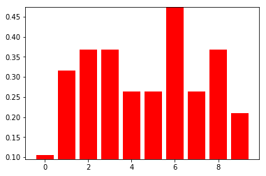

```python
plt.bar(range(len(scores1)),scores1,color='red')
plt.ylim([min(scores1)-0.01,max(scores1)])
```

```
(0.20052631578947366, 0.52631578947368418)
```

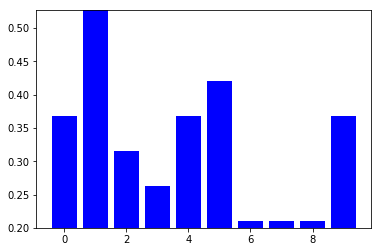

```python
plt.bar(range(len(scores2)),scores2,color='blue')
plt.ylim([min(scores2)-0.01,max(scores2)])
```

```
(0.14789473684210525, 0.42105263157894735)
```

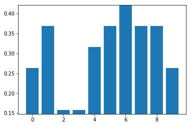

```python
plt.bar(range(len(scores3)),scores3)
plt.ylim([min(scores3)-0.01,max(scores3)])
```

Then we calculated the average recall scores, and we can see the model of 2 more dense layers is the best one.

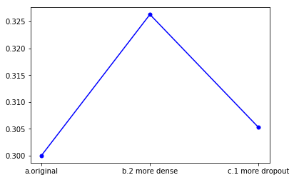

```python
plt.plot(['a.original','b.2 more dense','c.1 more dropout'], s,
    color='blue', marker='o',
    markersize=5)
```

## 2.3 Compare to MLP

```python
from sklearn.neural_network import MLPClassifier
from sklearn.metrics import roc_curve
from sklearn.model_selection import cross_val_score
from sklearn.metrics import make_scorer, recall_score
```

```python
from sklearn.preprocessing import OneHotEncoder

# now let's encode the integerr outputs as one hot encoded labels
ohe = OneHotEncoder()
X_train_ohe = ohe.fit_transform(df_train[categorical_headers_ints].values)
X_test_ohe = ohe.transform(df_test[categorical_headers_ints].values)

X_train = np.hstack((X_train_ohe.todense(),df_train[numeric_headers].values))
X_test = np.hstack((X_test_ohe.todense(),df_test[numeric_headers].values))
```

```python
mlp = MLPClassifier(hidden_layer_sizes=(50,10), max_iter=1000, alpha=1e-4,
                    solver='adam', tol=1e-4, random_state=1)
cv = StratifiedKFold(n_splits=10)
my_scorer = make_scorer(recall_score)
per_fold_eval_criteria = cross_val_score(estimator=mlp,
                                    X=X_train,
                                    y=y_train,
                                    cv=cv,
                                    scoring=my_scorer
                                   )
```

The recall score of MLP model.

```
(0.20052631578947366, 0.73684210526315785)
```

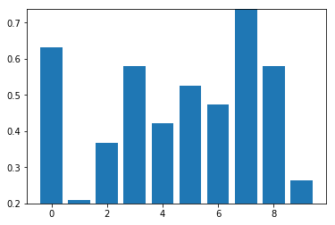

```python
plt.bar(range(len(per_fold_eval_criteria)),per_fold_eval_criteria)
plt.ylim([min(per_fold_eval_criteria)-0.01,max(per_fold_eval_criteria)])
```

```python
s4=np.array(per_fold_eval_criteria)
s.append(s4.mean())
```

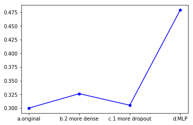

```python
plt.plot(['a.original','b.2 more dense','c.1 more dropout','d.MLP'], s,
    color='blue', marker='o',
    markersize=5)
```

Here we can see that the model of MLP is better than the model that we made.

```python
print(X_train.shape)
```

```
(1176, 51)
```

```python
from sklearn.metrics import roc_curve, auc
mlpm=mlp.fit(X_train,y_train)
```

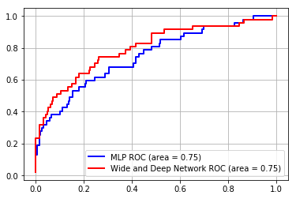

```python
from sklearn.metrics import roc_curve, auc

probas = mlpm.predict_proba(X_test)

fpr, tpr, thresholds = roc_curve(y_test,probas[:,1])
roc_auc = auc(fpr,tpr)
y_pred = model.predict_on_batch (X_ints_test + [X_test_num])
fpr1, tpr1, threshoulds = roc_curve(y_test,y_pred)
plt.plot(fpr,tpr,'k-',lw=2,label='MLP ROC (area = %0.2f)'
                   % roc_auc,color='blue')
plt.plot(fpr1,tpr1,'k-',lw=2,label='Wide and Deep Network ROC (area = %0.2f)'
                   % roc_auc,color='red')
plt.legend(loc='best')
plt.grid()
```

The RUC figure shows that our model is above the MLP model.

The recall score of MLP model is obviously higher than the score of our model, and the difference of RUC figures are not obvious. So we think the MLP model is better.

# 3 Exceptional work

First, we find the layers of our model.

```python
model.summary()
```

```
__________________________________________________________________________________________________
Layer (type)                    Output Shape         Param #     Connected to
==================================================================================================
BusinessTravel_int (InputLayer) (None, 1)            0
__________________________________________________________________________________________________
Department_int (InputLayer)     (None, 1)            0
__________________________________________________________________________________________________
EducationField_int (InputLayer) (None, 1)            0
__________________________________________________________________________________________________
Gender_int (InputLayer)         (None, 1)            0
__________________________________________________________________________________________________
JobRole_int (InputLayer)        (None, 1)            0
__________________________________________________________________________________________________
MaritalStatus_int (InputLayer)  (None, 1)            0
__________________________________________________________________________________________________
OverTime_int (InputLayer)       (None, 1)            0
__________________________________________________________________________________________________
embedding_1821 (Embedding)      (None, 1, 1)         3           BusinessTravel_int[0][0]
__________________________________________________________________________________________________
embedding_1822 (Embedding)      (None, 1, 1)         3           Department_int[0][0]
__________________________________________________________________________________________________
embedding_1823 (Embedding)      (None, 1, 2)         12          EducationField_int[0][0]
__________________________________________________________________________________________________
embedding_1824 (Embedding)      (None, 1, 1)         2           Gender_int[0][0]
__________________________________________________________________________________________________
embedding_1825 (Embedding)      (None, 1, 3)         27          JobRole_int[0][0]
__________________________________________________________________________________________________
embedding_1826 (Embedding)      (None, 1, 1)         3           MaritalStatus_int[0][0]
__________________________________________________________________________________________________
embedding_1827 (Embedding)      (None, 1, 1)         2           OverTime_int[0][0]
__________________________________________________________________________________________________
numeric_data (InputLayer)       (None, 23)           0
__________________________________________________________________________________________________
flatten_1821 (Flatten)          (None, 1)            0           embedding_1821[0][0]
__________________________________________________________________________________________________
flatten_1822 (Flatten)          (None, 1)            0           embedding_1822[0][0]
__________________________________________________________________________________________________
flatten_1823 (Flatten)          (None, 2)            0           embedding_1823[0][0]
__________________________________________________________________________________________________
flatten_1824 (Flatten)          (None, 1)            0           embedding_1824[0][0]
```

[output cut: 42 more lines]

```
concatenate_537 (Concatenate)   (None, 10)           0           flatten_1818[0][0]
                                                                 flatten_1819[0][0]
                                                                 flatten_1820[0][0]
__________________________________________________________________________________________________
dense_907 (Dense)               (None, 10)           110         dense_906[0][0]
__________________________________________________________________________________________________
concatenate_539 (Concatenate)   (None, 20)           0           concatenate_537[0][0]
                                                                 dense_907[0][0]
__________________________________________________________________________________________________
dense_908 (Dense)               (None, 1)            21          concatenate_539[0][0]
==================================================================================================
Total params: 4,323
Trainable params: 4,323
Non-trainable params: 0
__________________________________________________________________________________________________
```

```python
dense1_layer_model = Model(inputs=model.input,
                                     outputs=model.get_layer('embedding_1821').output)
dense1_output = dense1_layer_model.predict(X_ints_test + [X_test_num])
```

```python
layer1=model.layers[7:13]
layer2=model.layers[28:31]
layer3=layer1+layer2
layer3
```

```
[<keras.layers.embeddings.Embedding at 0x20c103ad7f0>,
 <keras.layers.embeddings.Embedding at 0x20c106c7ba8>,
 <keras.layers.embeddings.Embedding at 0x20c19a27f28>,
 <keras.layers.embeddings.Embedding at 0x20c10a18400>,
 <keras.layers.embeddings.Embedding at 0x20c10ad94e0>,
 <keras.layers.embeddings.Embedding at 0x20c1098add8>,
 <keras.layers.embeddings.Embedding at 0x20bf89b1dd8>,
 <keras.layers.embeddings.Embedding at 0x20c1051afd0>,
 <keras.layers.embeddings.Embedding at 0x20c1044aa58>]
```

```python
weights=[]
for i in layer3:
    weights.append(i.get_weights())
```

```python
weights1=layer3[6].get_weights()
```

```python
a=weights1[0]
```

[output not shown]

The weights are captured from embedding layer. and then use t-SNE to perform clustering of these output embeddings.

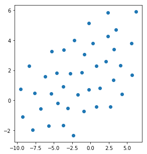

```python
from sklearn.manifold import TSNE
X_tsne = TSNE(learning_rate=100).fit_transform(a)


plt.figure(figsize=(10, 5))
plt.subplot(121)
plt.scatter(X_tsne[:, 0], X_tsne[:, 1])
```